# Lab 1: Linear models for quantitative genetics

BMI 206

William A. Johnson

Fri Oct 18 @11:59PM

### PART1: Analyzing provided genotype and phenotype data.

**Prepare the data.** Read in the genotype and phenotype matrices.

```r
genos = as.matrix(read.table("./genos.txt"))
phenos = as.matrix(read.table("./phenos.txt"))
```

Make a histogram of the phenotypes. Do they look normally distributed?

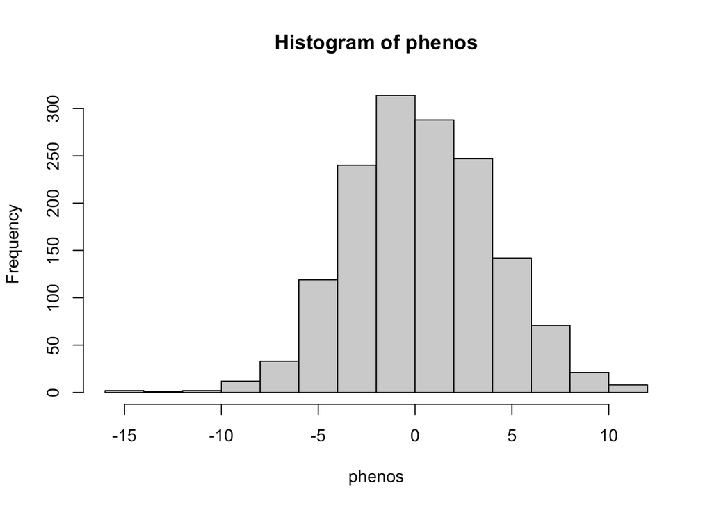

```r
hist(phenos)
```

*Yes, the phenotypes look normally distributed.*

How are the genotypes encoded?

```r
table(genos)
```

```
## genos
##       0       1       2
## 4773842 5447131 4779027
```

*The genotypes are encoded as allele counts (ordinal): `0`, `1`, or `2`.*

How many individuals are there in the dataset and how many SNPs? (Save them in `N` and `M`, respectively.)

```r
dim(genos)
```

```
## [1]  1500 10000
```

```r
# [1] 1500 10000

dim(phenos)
```

```
## [1] 1500    1
```

```r
# [1] 1500 1
N = dim(phenos)[1] # 1500 individuals
M = dim(genos)[2] # 10000 SNPs
```

*1500 individuals and 10000 SNPs.*

**Compute the *minor* allele frequency for every SNP. Check MAFs are <0.5.**

```r
# MAF = proportion of chromosomes with the less common nucleotide
MAFs = array(0,M)
for(i in 1:M) {
  g = genos[,i]
  allele_1_count = (2 * sum(g == 0)) + (sum(g == 1))
  allele_2_count = (2 * sum(g == 2)) + (sum(g == 1))
  minor_allele_count = min(allele_1_count, allele_2_count)
  MAFs[i] = minor_allele_count / (2 * N)
}
MAFs[1:10]
```

```
##  [1] 0.1516667 0.3226667 0.4126667 0.2156667 0.4626667 0.4826667 0.4863333
##  [8] 0.1516667 0.2990000 0.3310000
```

```r
max(MAFs) # [1] 0.5 // Woo!
```

```
## [1] 0.5
```

**Run a GWAS under an additive model and save the p-values, z-scores, and effect sizes.**

```r
pvalues = array(0,M)
zscores = array(0,M) # Estimate / std_error
betas = array(0,M)
for (i in 1:M) {
    g = genos[,i]
    res = summary(lm(phenos ~ g))
    zscores[i] = res$coefficients[2] / res$coefficients[4]
    pvalues[i] = res$coefficients[8]
    betas[i] = res$coefficients[2]
}
```

Summarize the effect sizes.

```r
summary(betas)
```

```
##      Min.   1st Qu.    Median      Mean   3rd Qu.      Max.
## -3.400728 -0.105822  0.002475  0.004204  0.113524  2.245525
```

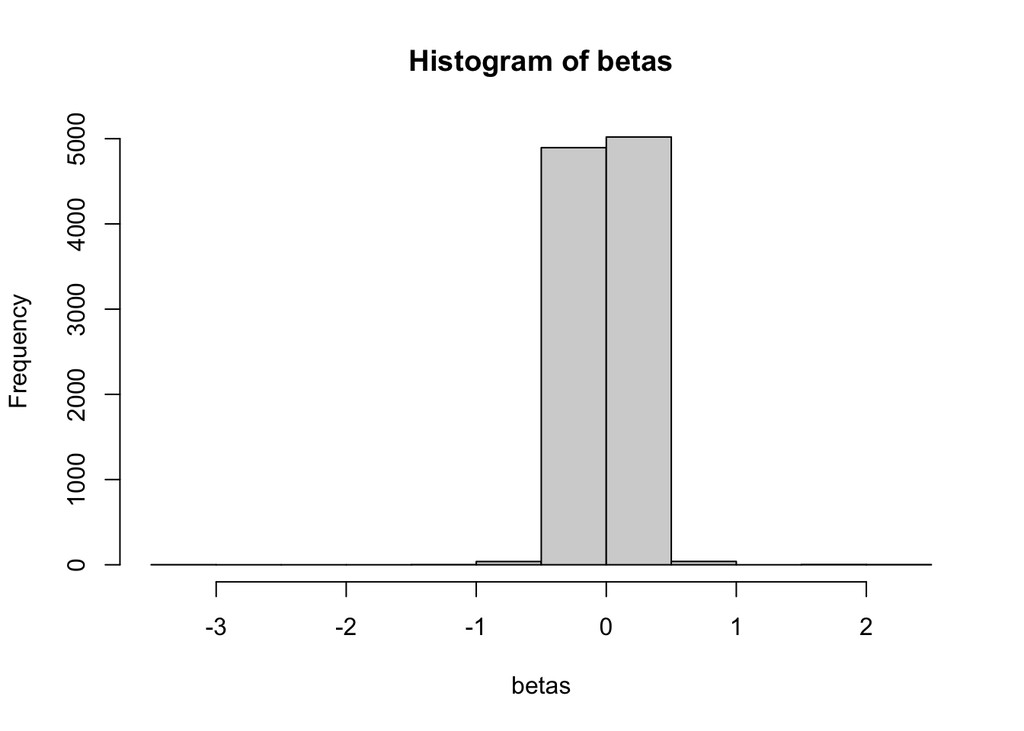

```r
hist(betas) # yikes
```

Are there any significantly associated SNPs? If so, which SNPs are they?

```r
alpha <- 0.05
pvalues_adjust <- p.adjust(pvalues, method = "bonferroni")
assoc = which(pvalues_adjust < alpha)
length(assoc) # [1] 10
```

```
## [1] 10
```

```r
assoc
```

```
##  [1]  1  2  3  4  5  6  7  8  9 10
```

*10 “significantly” associated SNPs after bonferonni correction with alpha = 0.05:*

*Significant SNPs: 1 2 3 4 5 6 7 8 9 10*

How big are their effect sizes? How significant are they?

*Average effect size is rather small: 0.5201. Larger effect sizes tend to have lower adjust p-values.*

```r
summary(betas[assoc])
```

```
##    Min. 1st Qu.  Median    Mean 3rd Qu.    Max.
## -3.4007 -0.7267  1.1585  0.5201  1.9541  2.2455
```

```r
summary(zscores[assoc])
```

```
##    Min. 1st Qu.  Median    Mean 3rd Qu.    Max.
## -21.022  -5.586   8.499   3.851  13.157  16.128
```

```r
summary(pvalues[assoc])
```

```
##      Min.   1st Qu.    Median      Mean   3rd Qu.      Max.
## 0.000e+00 0.000e+00 0.000e+00 7.153e-08 0.000e+00 6.309e-07
```

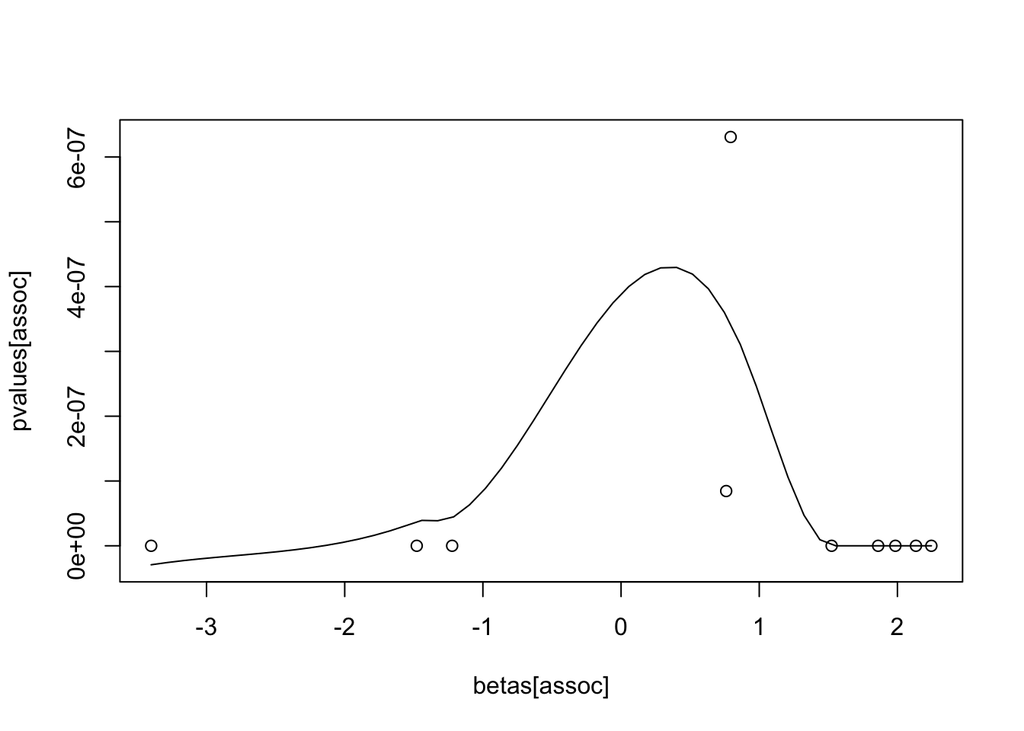

```r
scatter.smooth(x = betas[assoc], y = pvalues[assoc], family = "gaussian")
```

Draw a QQ plot for log10(p) values.

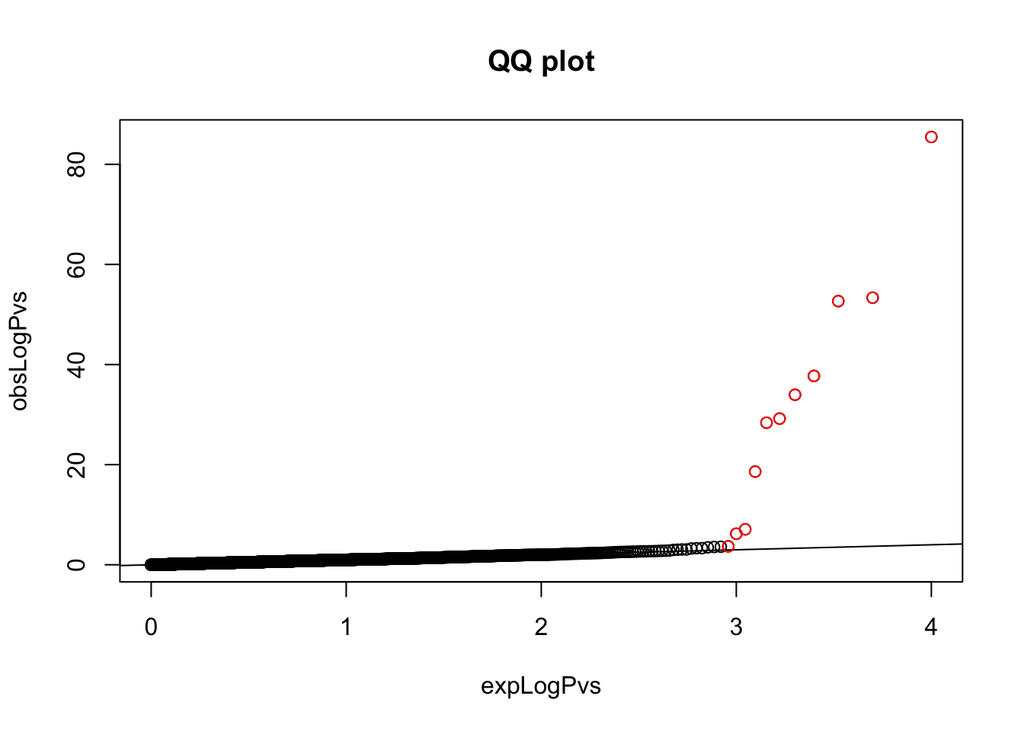

```r
obsLogPvs = sort(-log10(pvalues))
expLogPvs = sort(-log10(seq(1/M,1,1/M)))
plot(expLogPvs, obsLogPvs, main = 'QQ plot')
abline(a = 0, b = 1)
#label the significant SNPs red
points(expLogPvs[(M-length(assoc)):M],obsLogPvs[(M-length(assoc)):M],col="red")
```

Is there inflation? Use the chi-square statistics to check.

```r
chis = zscores^2
median(chis)
```

```
## [1] 0.4575746
```

```r
lambdaGC = median(chis)/0.454 # why .454?
lambdaGC # [1] 1.007873
```

```
## [1] 1.007873
```

*Lambda GC = `1.007873`. We use `0.454` because that’s the median of our chi distribution under the null hypothesis. I would argue that we have very little, if any, inflation, since our lambdaGC is very close to `1.0`.*